# Intervalos de confianza

Clase 2: Método pivotal

Luis Fernando Apáez Álvarez

21/12/2021

- Primeros ejemplos
- Distribución Bernoulli
- Ejercicios

Comenzaremos a ver varios ejemplos en donde aplicaremos el método pivotal, el cual queda formalmente establecido en la siguiente definición

**Definición (Método pivotal para intervalos de confianza):** Sean $X_{1},\ldots,X_{n}$ una muestra aleatoria de algúna distribución con función de densidad $f(0x,\theta)$, $\theta$ desconocido, $\alpha\in (0,1)$ y $Q=q(X_{1},\ldots,X_{n};\theta)$ una cantidad pivotal para $\theta$. Entoces existirán $a<b$ que depende de $\alpha$ tales que

$$\mathbb{P}(a<Q<b)=1-\alpha$$

Si para cada muestra $x_{1},\ldots,x_{n}$ tenemos que $a<q(x_{1},\ldots, x_{n};\theta)<b$ si y sólo si $t_{1}(x_{1},\ldots, x_{n})<\tau(\theta)<t_{2}(x_{1},\ldots, x_{n})$ para funciones $t_{1}$ y $t_{2}$ que no depende de $\theta$, entonces $(t_{1},t_{2})$ es un intervalo del $(1-\alpha)\cdot 100\%$ de confianza para $\tau(\theta)$

## Primeros ejemplos

**Ejemplo 1:** Sea $X\sim Unif(0,\theta)$. Hallar un intervalo del $95\%$ de confianza para $\theta$.

**Solución:** Sabemos que

- $f_{X}(x,\theta)=\frac{1}{\theta}\mathbb{I}_{(0,\theta)}(x)$
- $F_{X}(x)=\frac{x}{\theta}$

Luego, debemos proponer alguna función de $X$ y de $\theta$ y verificar que su distribución no dependa de $\theta$, con lo cual conseguiríamos una cantidad pivotal. Proponemos $Y=X/\theta$ y veamos que

$$\begin{align*}
F_{Y}(y)&=\mathbb{P}(Y\leq y)=\mathbb{P}(X/\theta\leq y)\\
&=\mathbb{P}(X\leq \theta y)=F_{X}(\theta y)\\
&=y
\end{align*}$$

por lo que $Y\sim Unif(0,1)$ concluyendo así que $Y$ es una cantidad pivotal para $\theta$. Procedemos después a hallar dos números $a<b$ tales que

$$\mathbb{P}(a<Y< b)=0.95 \ \ \Rightarrow \ \ F_{Y}(b)-F_{Y}(a)=0.95 \ \ \Rightarrow \ \ b-a=0.95$$

de modo que podemos fijar un valor de $a$ tal que $b=0.95+a$. Por ejemplo podríamos tomar $a=0.05$ y por ende $b=1$, etcétera. Después despejamos $\theta$ de $a<Y<b$:

$$a<\frac{X}{\theta}<b \ \ \Rightarrow \ \ \frac{1}{a}>\frac{\theta}{X}>\frac{1}{b} \ \ \Rightarrow \ \ \frac{X}{b}<\theta <\frac{X}{a} \ \ \Rightarrow \ \ \frac{X}{0.95+a}<\theta <\frac{X}{a}$$

de modo que

$$\mathbb{P}(a<Y< b)=0.95 \ \ \Leftrightarrow \ \ \mathbb{P}\left(\frac{X}{0.95+a}<\theta <\frac{X}{a} \right)=0.95$$

con lo cual conseguimos que $\left(\frac{X}{0.95+a},\frac{X}{a} \right)$ sea un intervalo del $95\%$ de confianza para $\theta$.

Notemos que podría ser de interés hallar intervalos de confianza con menor longitud esperada (pues recordemos que los extremos del intervalo son variables aleatorias). De tal manera, si consideramos la longitud del intervalo encontrado

$$L=\frac{X}{a}-\frac{X}{0.95+a}$$

tendríamos que la longitud del intervalo de confianza esperado es

$$\mathbb{E}(L)=\left(\frac{1}{a}-\frac{1}{0.95+a}\right)\mathbb{E}(X)=\left(\frac{1}{a}-\frac{1}{0.95+a}\right)\frac{\theta}{2}$$

lo cual se procedería a minimizar, lo que equivale a hallar el valor de $a$ que minimice $\mathbb{E}(L)$. Dicho mínimo se alcanza cuando $a=0.05$, por lo que $b=1$ y por lo tanto

$$\left(X,\frac{1}{0.05}X\right)$$

sea el intervalo de confianza de longitud mínima.

**Ejemplo 2:** Sea $X\sim exp(1/\theta)$. Hallar un intervalo del $90\%$ de confianza para $\theta$.

**Solución:** Sabemos que

- $f_{X}(x;\theta)=\frac{1}{\theta}e^{-x/\theta}$
- $F_{X}(x)=1-e^{-x/\theta}$

Para este ejemplo podemos utilizar también $Y=\dfrac{X}{\theta}$ el cual será una cantidad pivotal para $\theta$. En efecto, como $Y$ es una función de $X$ y de $\theta$ basta ver cuál es su distribución:

$$\begin{align*}
F_{Y}(y)&=\mathbb{P}(Y\leq y)=\mathbb{P}\left(\frac{X}{\theta}\leq y\right)\\
&=\mathbb{P}(X\leq \theta y)=F_{X}(\theta y)\\
&=1-e^{-y}
\end{align*}$$

de modo que $Y\sim exp(1)$. Por tanto $Y$ es una cantidad pivotal para $\theta$. Así, buscamos dos números $a<b$ tales que
$$\mathbb{P}\left(a<\frac{X}{\theta}<b\right)=0.90$$

A diferencia del ejemplo anterior no es tan directo la determinación de los valores de $a$ y $b$, sin embargo pueden tomarse tales que cumplan la siguiente condición

$$\mathbb{P}(X/\theta <a)=\frac{\alpha}{2}=0.05 \ \ \ \ \textrm{y} \ \ \ \ \mathbb{P}(X/\theta>b)=\frac{\alpha}{2}=0.05$$

de donde

$$0.05=\mathbb{P}(X<\theta a)=F_{X}(\theta a)=1-e^{-a} \ \ \Rightarrow \ \ a=-ln(0.95)\approx 0.051$$

y también

$$0.05=\mathbb{P}(X>\theta b)=1- F_{X}(\theta b)=e^{-b} \ \ \Rightarrow \ \ b=-ln(0.05)\approx 2.996$$

De tal manera, $\left(\frac{X}{2.996}<\theta <\frac{X}{0.051}\right)$ es un intervalo del $90\%$ de confianza para $\theta$.

**Ejemplo 3:** Sea $X_{1},\ldots,X_{n}$ una muestra aleatoria de la distribución $exp(\theta)$. Hallar un intervalo de confianza del $(1-\alpha)\cdot 100\%$ para $\theta$, con $\alpha\in(0,1)$.

Consideramos la estadística $T=\sum_{i=1}^{n}X_{i}\sim \Gamma(n,\theta)$, la cual no puede ser considerada como cantidad pivotal pues no depende de $\theta$ y sin embargo su distribución si depende de ella. Notemos que para cualquier $c>0$ y $X$ variable aleatoria se satisface que

$$f_{cX}(x)=\frac{1}{c}f_{X}(x/c) \ \ \ \ \textrm{y} \ \ \ \ F_{cX}(x)=F_{X}(x/c)$$

Puede considerarse entonces que

$$c\sum_{i=1}^{n}X_{i}\sim \Gamma(n,\theta /c)$$

luego, como $\theta$es un valor fijo pero desconocido, podemos considerar entonces que

$$\theta\sum_{i=1}^{n}X_{i}\sim \Gamma(n,1)$$

teniendo así que $Q=\theta\sum_{i=1}^{n}X_{i}\sim \Gamma(n,1)$ es una cantidad pivotal para $\theta$.

Después, se buscan $a<b$ tales que

$$\mathbb{P}\left(a<\theta\sum_{i=1}^{n}X_{i}<b
\right)=1-\alpha$$

Una manera de hallar los valores de $a$ y $b$ es como se hizo en el caso en que solo teniamos una variable aleatoria, es decir, bastará con considerar

$$\mathbb{P}\left(\theta\sum_{i=1}^{n}X_{i}<a\right)=\frac{\alpha}{2} \ \ \ \ \textrm{y} \ \ \ \mathbb{P}\left(\theta\sum_{i=1}^{n}X_{i}>b\right)=\frac{\alpha}{2}$$

Dichos valores son $a=\gamma_{1-\alpha/2}$ y $b=\gamma_{\alpha/2}$

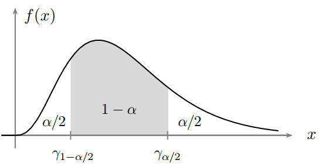

donde $\gamma_{1-\alpha/2}$ y $\gamma_{\alpha/2}$ denotan los cuantiles $1-\alpha/2$ y $\alpha/2$ de una distribución $\Gamma(n,1)$. De tal suerte

$$\mathbb{P}\left(a<\theta\sum_{i=1}^{n}X_{i}<b
\right)=1-\alpha \ \ \ \Leftrightarrow \ \ \mathbb{P}\left(\frac{\gamma_{1-\alpha/2}}{\sum_{i=1}^{n}X_{i}}<\theta<\frac{\gamma_{\alpha/2}}{\sum_{i=1}^{n}X_{i}}
\right)=1-\alpha$$

siendo así que un intervalo de confianza para $\theta$ es

$$\left(\frac{\gamma_{1-\alpha/2}}{\sum_{i=1}^{n}X_{i}},\frac{\gamma_{\alpha/2}}{\sum_{i=1}^{n}X_{i}}\right)$$

## Distribución Bernoulli

Sea $X_{1},\ldots,X_{n}$ una muestra aleatoria de la distribución $Ber(\theta)$. Sabemos que $\overline{X}$ es un estimador puntual para $\theta$ donde

$$\mathbb{E}\left[\overline{X}\right]=\theta \ \ \ \ \textrm{y} \ \ \ Var\left[\overline{X}\right]=\frac{\theta(1-\theta)}{n}$$

Usamos luego el *Teorema central del límite* para obtener que

$$\frac{\overline{X}-\theta}{\sqrt{\theta(1-\theta)/n}}\sim \mathcal{N}(0,1)$$

y buscamos ahora dos números $a<b$ tales que

$$\mathbb{P}\left(a<\frac{\overline{X}-\theta}{\sqrt{\theta(1-\theta)/n}}<b\right)\approx 1-\alpha \hspace{3cm}(\ast)$$

Para hallar dichos valores utilizaremos la idea del **ejemplo 3**, donde tomaremos $a=-z_{\alpha/2}$ y $b=z_{\alpha/2}$, siendo éstos cuantiles de la distribución normal

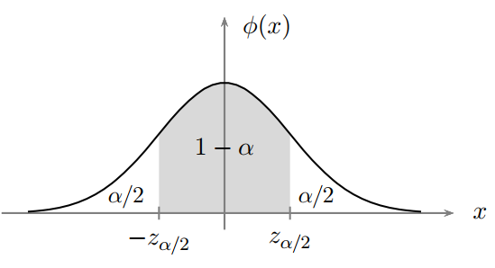

El problema radica en el despeje de $\theta$ dentro de la probabilidad de la ecuación $(\ast)$.

Una solución para ello es utilizar que $\theta(1-\theta)\leq 1/4$, por lo que $\sqrt{\theta(1-\theta)/n}\leq 1/2\sqrt{n}$. Luego

$$\begin{align*}
-\frac{z_{\alpha/2}}{2\sqrt{n}}&<-z_{\alpha/2}\sqrt{\theta(1-\theta)/n}<\overline{X}-\theta\\
&<z_{\alpha/2}\sqrt{\theta(1-\theta)/n}<\frac{z_{\alpha/2}}{2\sqrt{n}}
\end{align*}$$

obteniendo así el intervalo de confianza, aproximado, para $\theta$

$$\left(\overline{X}-\frac{z_{\alpha/2}}{2\sqrt{n}},\overline{X}+\frac{z_{\alpha/2}}{2\sqrt{n}}\right)$$

## Ejercicios

$1)$ Del ejemplo anterior, halle otro intervalo de confianza para $\theta$ siguiendo los siguientes pasos:

- Considera que $-z_{\alpha/2}<\frac{\overline{X}-\theta}{\sqrt{\theta(1-\theta)/n}}<z_{\alpha/2}$ puede escribirse como $\left|\overline{X}-\theta\right|<z_{\alpha/2}\sqrt{\theta(1-\theta)/n}$ y desarrolla elevando al cuadrado.
- Obtendrás una desigualdad cuadrática considerando como variable a $\theta$. Considera la igualdad cuadrática para hallar dos raíces, digamos $\theta_{1}$ y $\theta_{2}$.
- Tendrás que la desigualdad se satisface cuando $\theta_{1}<\theta<\theta_{2}$ por lo que ya puedes deducir el intervalo de confianza para $\theta$

$2)$ Consideremos una muestra aleatoria de la distribución $\mathcal{N}(\theta,\sigma^{2})$, con $\sigma^{2}$ conocida. Halla un intervalo de confianza para $\theta$.

**Solución:** Sabemos que $\overline{X}\sim \mathcal{N}(\theta,\sigma^{2}/n)$, por lo que

$$Q=\frac{\overline{X}-\theta}{\sigma/\sqrt{n}}\sim \mathcal{N}(0,1)$$

siendo así que $Q$ es una cantidad pivotal para $\theta$. Tenemos pues que existen $a<b$ tales que

$$\mathbb{P}\left(-z_{\alpha/2}<\frac{\overline{X}-\theta}{\sigma/\sqrt{n}}<z_{\alpha/2}\right)=1-\alpha$$

por lo tanto, un intervalo de confianza para $\theta$ cuando la varianza es conocida es

$$\left(\overline{X}-\frac{z_{\alpha/2}}{\sigma/\sqrt{n}}<\theta<\overline{X}+\frac{z_{\alpha/2}}{\sigma/\sqrt{n}}\right)$$

$2.1)$ Ahora bien, halla un intervalo de confianza para $\theta$ considerando el caso en que $\sigma^{2}$ es desconocida. Para ello utiliza que

$$\frac{\overline{X}-\theta}{S/\sqrt{n}}\sim t_{n-1}$$

donde $S$ es la varianza muestral.

$2.2)$ Halla un intervalo de confianza para $\sigma^{2}$ utilizando el hecho de que

$$(n-1)\frac{S}{\sigma^{2}}\sim \chi^{2}_{n-1}$$